# iml_hw2

Michal_Raszkowski

26 03 2021

W ninejszym dokumencie wykorzystamy techniki wyjaśnialności przedstawione na ostatnim wykładzie do analizy modelu z pierwszej pracy domowej. W związku z tym pomijam części związane z przygotowaniem danych i uczeniem modelu lasu losowego.

```r
#trenujemy las losowy z parametrami uzyskanymi w pierwszej pd
rf <- ranger(
    formula         = price ~ .,
    data            = train_data,
    num.trees       = 500,
    mtry            = 12,
    min.node.size   = 2,
    sample.fraction = 0.632,
    seed            = 13
  )
```

### Dekompozycja za pomocą metody SHAP

Wybierzmy dwie losowe obserwacje ze zbioru testowego.

```
##     price pred_price
## 12 468000   478842.9
## 32 280000   302550.1
```

Różnica pomiędzy predykcją a faktyczną ceną jest stosunkowo niewielka. Zobaczmy jakie czynniki miały największy wpływ na predykcję ceny dla tych dwóch mieszkań.

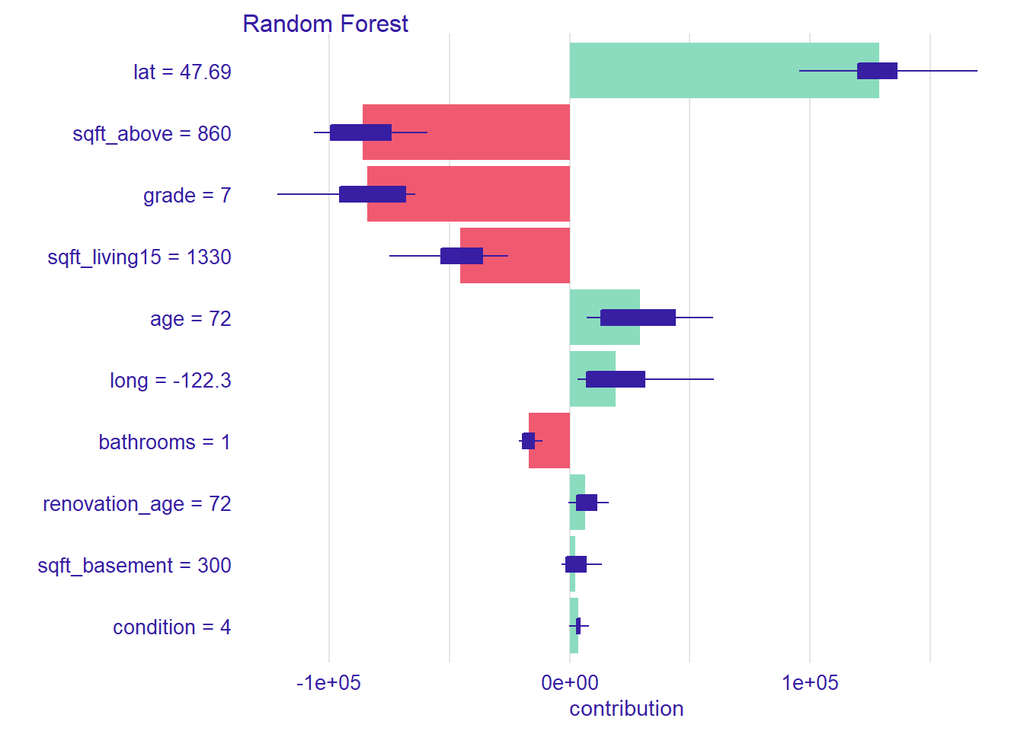

Dla pierwszego mieszkania głównym składnikiem podnoszącym przewidywaną cenę jest położenie - szczególnie wybija się kontrybucja zmiennej *lat*. Prawdopodobnie jest to związane z bliskim położeniem względem dogodnej lokalizacji (np. centrum miasta). Na obniżenie ceny w modelu głównie wpływa przeciętny stan i wygląd budynku (*grade*), niska powierzchnia mieszkaniowa oraz (co ciekawe) średnia powierzchnia mieszkaniowa 15 domów w sąsiedztwie. To ostatnie możnaby tłumaczyć mniejszym metrażem względem mieszkań w okolicy, ale hipotezę tę zdaje się obalać następny przykład.

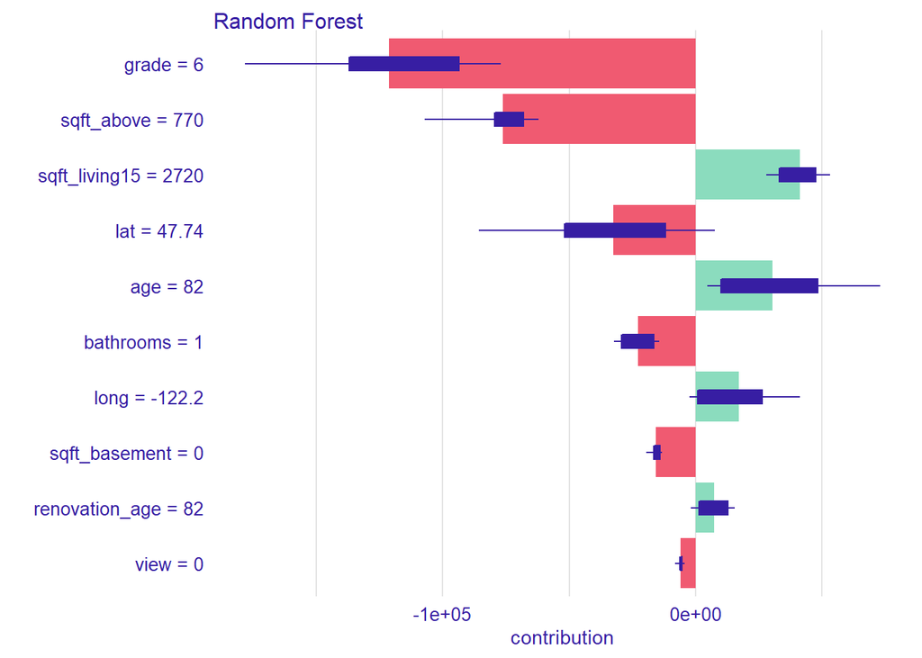

### Obserwacja o innych wpływowych parametrach

W poprzednich przykładach ocena stanu i wyglądu budynku oraz metraż miały największy wpływ na predykcję ceny. Spróbujmy znaleźć obserwację dla której te zmienne nie są najważniejsze.

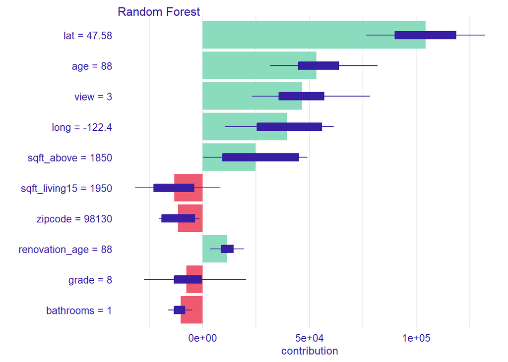

Dla powyższego lokum na cenę najbardziej wpływa położenie, widok oraz wiek budynku. Sugeruje to, że głównym atutem tej nieruchomości jest jego okolica, przez co stan budynku i jego metraż odgrywa tu mniejszą rolę.

### Ta sama wartość, odwrotny wpływ

Ustalając wartość stanu i wyglądu budynku *grade*=8 zobaczymy, że dla jednej obserwacji wpływa ona na wzrost ceny, zaś dla innej ją obniża.

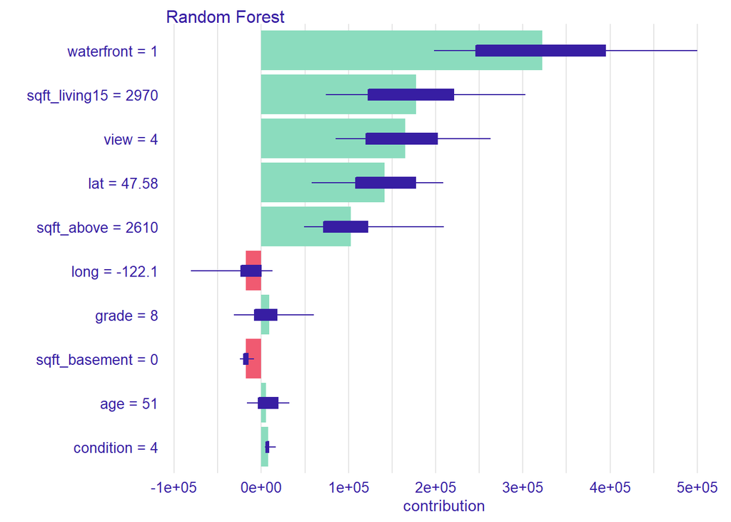

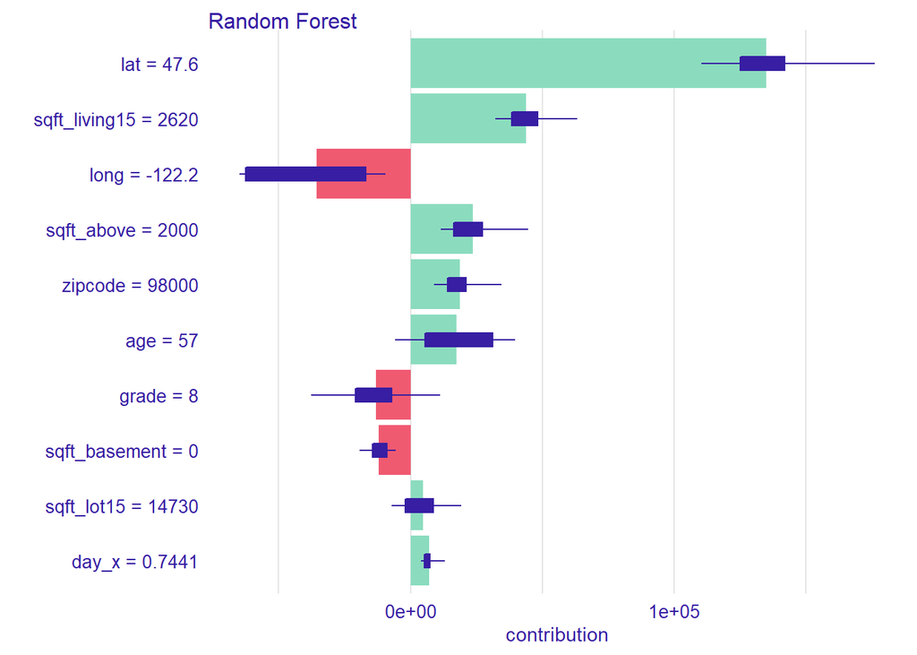

Zwróćmy przy tym uwagę, że w obu przypadkach zmienna ta nie wywiera największego wpływu na cenę. Wzrost ceny w pierwszym przypadku może wynikać z połaczenia z ładnym widokiem i bliskością do akwenu wodnego, którego w drugim przypadku nie mamy.

### Porównanie z modelem liniowym

Na koniec porównajmy dekompozycję z pierwszego przykładu z dekompozycją tej samej obseracji przy zastosowaniu modelu liniowego z regularyzacją elastic net.

```r
elnet <- train(
  price ~., data = train_data, method = "glmnet",
  trControl = trainControl("cv", number = 5),
  tuneLength = 5
)
```

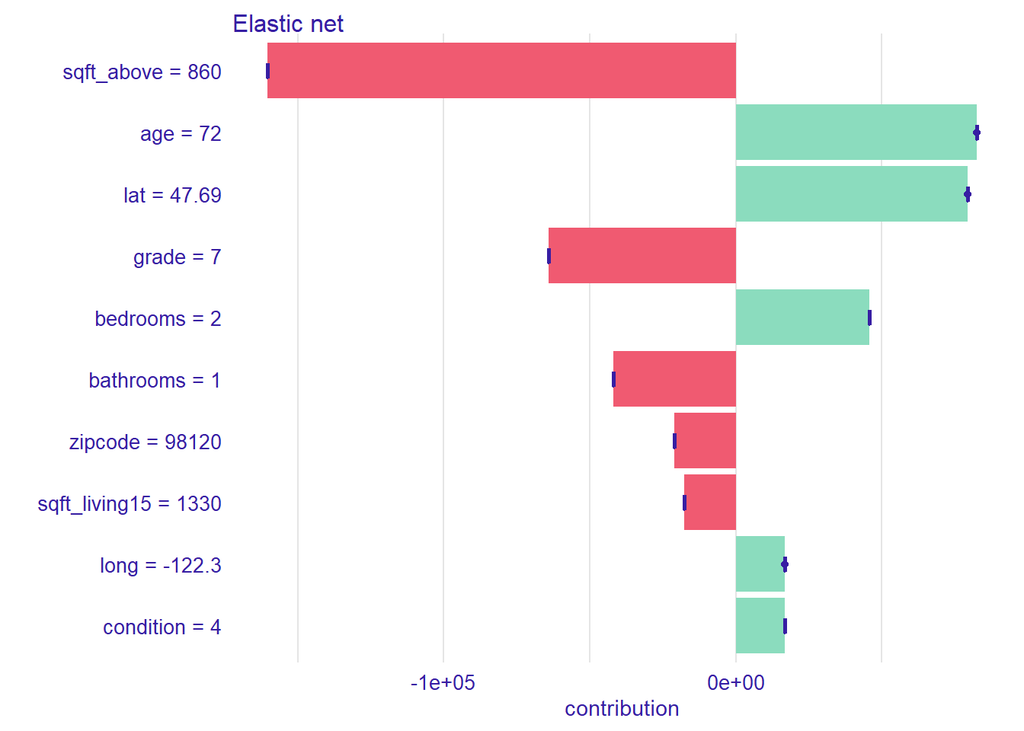

Dekompozycja znacząco się zmieniła - na pierwsze miejsce wskoczył metraż deklasując zmienną *lat* na 3-cie miejsce. Wzrosło też znaczenie wieku budynku oraz liczby sypialni. Co najciekawsze, kolejność zmiennych w warunkowaniach praktycznie nie ma znaczenia (punktowe znaczniki granatowe) w przeciwieństwie do przykładów z lasem losowym.